# Multivariate Time Series Forecasting

Fred Viole

# 1 Install latest version of `NNS (>=0.4.7)`

```r
require(devtools); install_github('OVVO-Financial/NNS', ref = "NNS-Beta-Version")

library(NNS)
```

# 2 VAR Example with 3 Variables: Fed Funds, Real GNP, and Inflation

Using the log differences of each `Real GNP` and `Inflation`, the previous method creates lowest frequency series. In this illustrative VAR example from Lutz Kilian[^1], `Fed Funds` (monthly) is averaged over 3-period windows to align with quarterly GNP data.

```r
library(vars)

# Load Variables
FF = read.csv("fedfunds.txt",header=FALSE,sep = '\t')

realgnp = read.csv("realgnp.txt",header=FALSE,sep = '\t')
drgdp = diff(log(realgnp[,3]))*100

gnpdeflator = read.csv("gnpdeflator.txt",header=FALSE,sep = '\t')
infl = diff(log(gnpdeflator[,3]))*100

irate = numeric()
for(i in seq(1,length(FF[,3]),3)){
  irate[i] = mean(FF[i:(i+2),3])
}

irate = na.omit(irate)


y = cbind("Diff Real GDP"=drgdp[1:213],"Interest Rate"=irate,"Inflation"=infl[1:213])

head(y)
```

```
##      Diff Real GDP Interest Rate Inflation
## [1,]     1.9944940     0.9866667 0.2810368
## [2,]     2.8100061     1.3433333 0.4818031
## [3,]     1.5928111     1.5000000 0.4148308
## [4,]     1.3345828     1.9400000 0.7089943
## [5,]     0.6089062     2.3566667 0.9778623
## [6,]    -0.3111535     2.4833333 0.9998818
```

```r
tail(y)
```

```
##        Diff Real GDP Interest Rate Inflation
## [208,]   -0.01158863      5.246667 0.6891565
## [209,]    0.84719231      5.246667 0.3501309
## [210,]    0.06757442      5.256667 1.1124581
## [211,]    0.91316852      5.250000 0.5562536
## [212,]    1.05338427      5.073333 0.3451964
## [213,]    0.66741511      4.496667 0.4471854
```

## 2.1 Forecast next 12 Quarters Using All Methods

We will withhold 12 quarters of observations as the `test` set. Let’s see how accurate a VAR, a random forest and `NNS` are…

Why a random forest? The Bank of England has recently been posting working papers utilizing machine learning, specifically random forests:

- [Machine Learning at Central Banks](https://techpolicyinstitute.org/wp-content/uploads/2018/02/Joseph-machine-learning-at-central-banks.pdf)
- [Predicting Bank Distress in the UK with Machine Learning](https://www.bankofengland.co.uk/-/media/boe/files/working-paper/2019/predicting-bank-distress-in-the-uk-with-machine-learning.pdf)

### 2.1.1 VAR

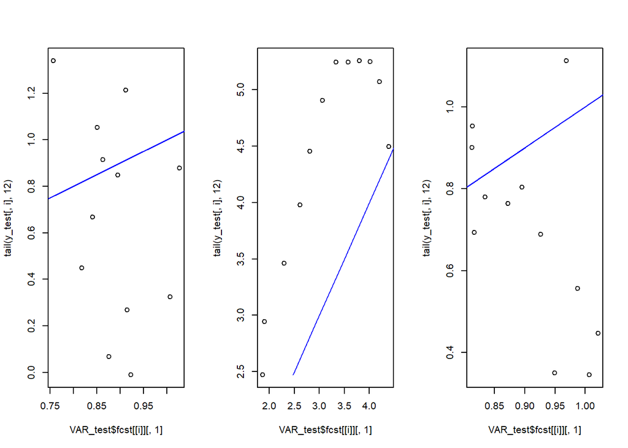

```r
# Forecast next 12 quarters
h = 12

# Create train and test sets for both versions
y_train = head(y, dim(y)[1] - h)
y_test = tail(y, h)

# 4 quarterly lags used in VAR
VAR_train =  VAR(y = y_train, p = 4)
VAR_test = predict(VAR_train, n.ahead = 12)

par(mfrow=c(1,3))


# Plot predictions and actual values
for(i in 1:3){
  plot(VAR_test$fcst[[i]][,1], tail(y_test[,i],12))
  lines(tail(y_test[,i],12),tail(y_test[,i],12),col='blue')
}
```

```r
VAR_predictions = cbind(rbind(Diff.Real.GDP=cor(VAR_test$fcst[[1]][,1], tail(y_test[,1],12))^2,
                              Interest.Rate=cor(VAR_test$fcst[[2]][,1], tail(y_test[,2],12))^2,
                              Inflation=cor(VAR_test$fcst[[3]][,1], tail(y_test[,3],12))^2)
                        )

colnames(VAR_predictions) = c("VAR Estimates R2 to Actual Values")

VAR_predictions
```

```
##               VAR Estimates R2 to Actual Values
## Diff.Real.GDP                         0.1021556
## Interest.Rate                         0.7075125
## Inflation                             0.3193175
```

The correlations for the VAR forecast of `realgdp` and `inflation` versus the actual out-of-sample values were negative!

### 2.1.2 `NNS` and Random Forest

#### 2.1.2.1 Function to Generate Lagged Variables

The following code is to generate a matrix of lagged variables to be used in both `NNS` and Random Forest routines.

```r
lag.fx <- function(x,tau){
  colheads <- NULL

  if(is.null(dim(x)[2])) {
    colheads <- noquote(as.character(deparse(substitute(x))))
    x <- t(t(x))
  }

  j.vectors <- list()

  for(j in 1:ncol(x)){
      if(is.null(colheads)){
          colheads <- colnames(x)[j]

          colheads <- noquote(as.character(deparse(substitute(colheads))))
      }

      x.vectors <- list()
      heads <- paste0(colheads, ".tau.")
      heads <- gsub('"', '' ,heads)

      for (i in 0:tau){
          x.vectors[[paste(heads, i, sep = "")]] <- numeric(0L)
          start <- tau - i + 1
          end <- length(x[,j]) - i
          x.vectors[[i + 1]] <- x[start : end, j]
      }

      j.vectors[[j]] <- do.call(cbind,x.vectors)
      colheads <- NULL
  }

  return(as.data.frame(do.call(cbind,j.vectors)))
}


# Test it
set.seed(123)
x <- rnorm(10); y <- rnorm(10); z <- rnorm(10)

lag.fx(cbind(x=x,y=y,z=z),3)
```

| x.tau.0 | x.tau.1 | x.tau.2 | x.tau.3 | y.tau.0 | y.tau.1 | y.tau.2 | y.tau.3 | z.tau.0 | z.tau.1 | z.tau.2 | z.tau.3 |
| --- | --- | --- | --- | --- | --- | --- | --- | --- | --- | --- | --- |
| 0.07050839 | 1.55870831 | -0.23017749 | -0.56047565 | 0.1106827 | 0.4007715 | 0.3598138 | 1.2240818 | -0.7288912 | -1.0260044 | -0.2179749 | -1.0678237 |
| 0.12928774 | 0.07050839 | 1.55870831 | -0.23017749 | -0.5558411 | 0.1106827 | 0.4007715 | 0.3598138 | -0.6250393 | -0.7288912 | -1.0260044 | -0.2179749 |
| 1.71506499 | 0.12928774 | 0.07050839 | 1.55870831 | 1.7869131 | -0.5558411 | 0.1106827 | 0.4007715 | -1.6866933 | -0.6250393 | -0.7288912 | -1.0260044 |
| 0.46091621 | 1.71506499 | 0.12928774 | 0.07050839 | 0.4978505 | 1.7869131 | -0.5558411 | 0.1106827 | 0.8377870 | -1.6866933 | -0.6250393 | -0.7288912 |
| -1.26506123 | 0.46091621 | 1.71506499 | 0.12928774 | -1.9666172 | 0.4978505 | 1.7869131 | -0.5558411 | 0.1533731 | 0.8377870 | -1.6866933 | -0.6250393 |
| -0.68685285 | -1.26506123 | 0.46091621 | 1.71506499 | 0.7013559 | -1.9666172 | 0.4978505 | 1.7869131 | -1.1381369 | 0.1533731 | 0.8377870 | -1.6866933 |
| -0.44566197 | -0.68685285 | -1.26506123 | 0.46091621 | -0.4727914 | 0.7013559 | -1.9666172 | 0.4978505 | 1.2538149 | -1.1381369 | 0.1533731 | 0.8377870 |

```r
# Compare to last values of each variable
tail(x); tail(y); tail(z)
```

```
## [1]  0.1292877  1.7150650  0.4609162 -1.2650612 -0.6868529 -0.4456620
```

```
## [1] -0.5558411  1.7869131  0.4978505 -1.9666172  0.7013559 -0.4727914
```

```
## [1] -0.6250393 -1.6866933  0.8377870  0.1533731 -1.1381369  1.2538149
```

#### 2.1.2.2 Predictions

##### 2.1.2.2.1 1 Year Lag $(\tau = 4)$, 3 Year Forecast $(h = 12)$

```r
library(randomForest)

tau = 4

y = cbind(lag.fx(cbind(GDP=drgdp,FF=irate,INF=infl),tau))

head(y)
```

|  | GDP.tau.0 | GDP.tau.1 | GDP.tau.2 | GDP.tau.3 | GDP.tau.4 | FF.tau.0 | FF.tau.1 | FF.tau.2 | FF.tau.3 | FF.tau.4 | INF.tau.0 | INF.tau.1 | INF.tau.2 | INF.tau.3 | INF.tau.4 |
| --- | --- | --- | --- | --- | --- | --- | --- | --- | --- | --- | --- | --- | --- | --- | --- |
| 1 | 0.60890621 | 1.33458282 | 1.59281113 | 2.8100061 | 1.9944940 | 2.356667 | 1.940000 | 1.500000 | 1.343333 | 0.9866667 | 0.9778623 | 0.7089943 | 0.4148308 | 0.4818031 | 0.2810368 |
| 2 | -0.31115349 | 0.60890621 | 1.33458282 | 1.5928111 | 2.8100061 | 2.483333 | 2.356667 | 1.940000 | 1.500000 | 1.3433333 | 0.9998818 | 0.9778623 | 0.7089943 | 0.4148308 | 0.4818031 |
| 3 | 0.80628335 | -0.31115349 | 0.60890621 | 1.3345828 | 1.5928111 | 2.693333 | 2.483333 | 2.356667 | 1.940000 | 1.5000000 | 0.5964170 | 0.9998818 | 0.9778623 | 0.7089943 | 0.4148308 |
| 4 | -0.06397953 | 0.80628335 | -0.31115349 | 0.6089062 | 1.3345828 | 2.810000 | 2.693333 | 2.483333 | 2.356667 | 1.9400000 | 1.2379244 | 0.5964170 | 0.9998818 | 0.9778623 | 0.7089943 |
| 5 | 1.52782465 | -0.06397953 | 0.80628335 | -0.3111535 | 0.6089062 | 2.926667 | 2.810000 | 2.693333 | 2.483333 | 2.3566667 | 0.4133639 | 1.2379244 | 0.5964170 | 0.9998818 | 0.9778623 |
| 6 | 0.74655850 | 1.52782465 | -0.06397953 | 0.8062834 | -0.3111535 | 2.933333 | 2.926667 | 2.810000 | 2.693333 | 2.4833333 | 1.3514959 | 0.4133639 | 1.2379244 | 0.5964170 | 0.9998818 |

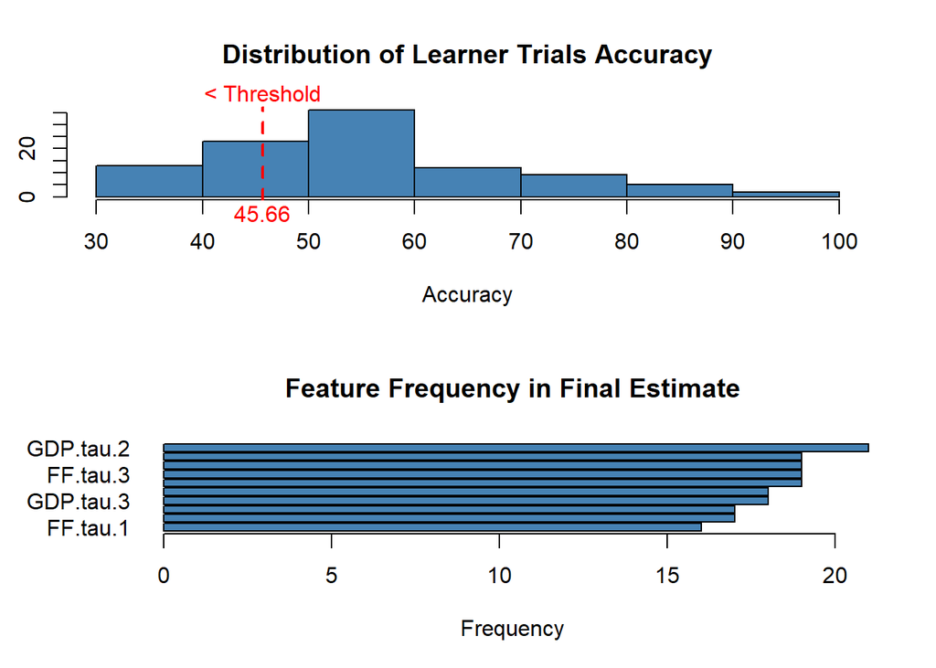

```
## [1] "NNS Boost R2: 0.136854354118108"
```

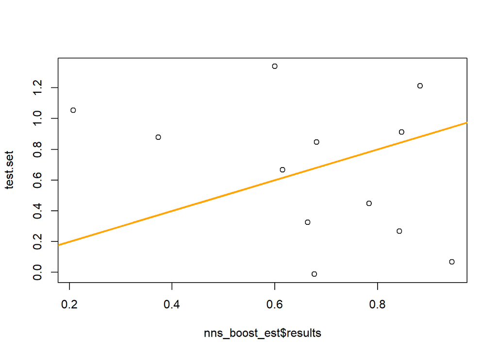

```
## [1] "NNS Regression R2: 0.937763997127819"
```

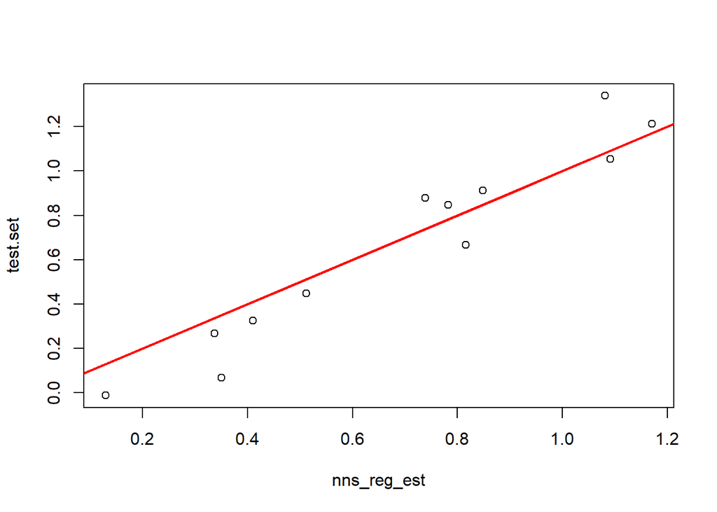

```
## [1] "Random Forest R2: 0.00565430022435073"
```

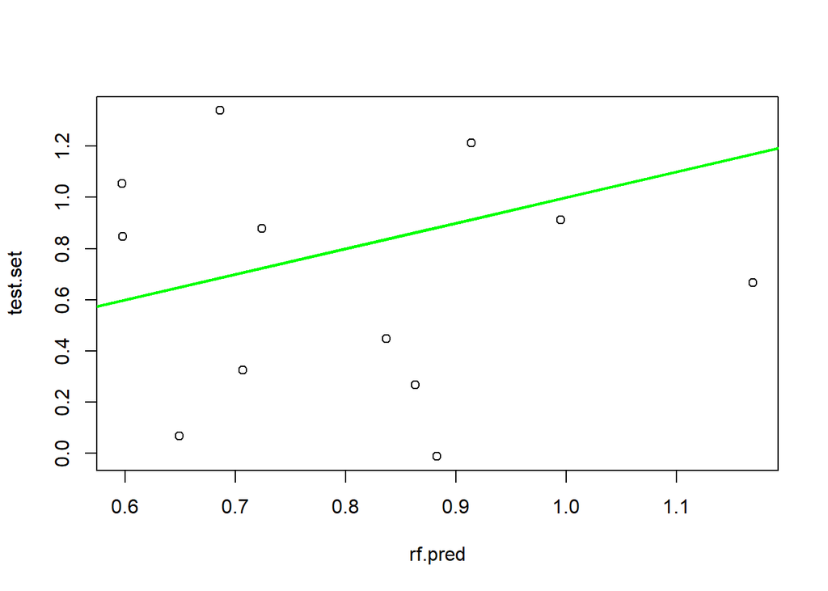

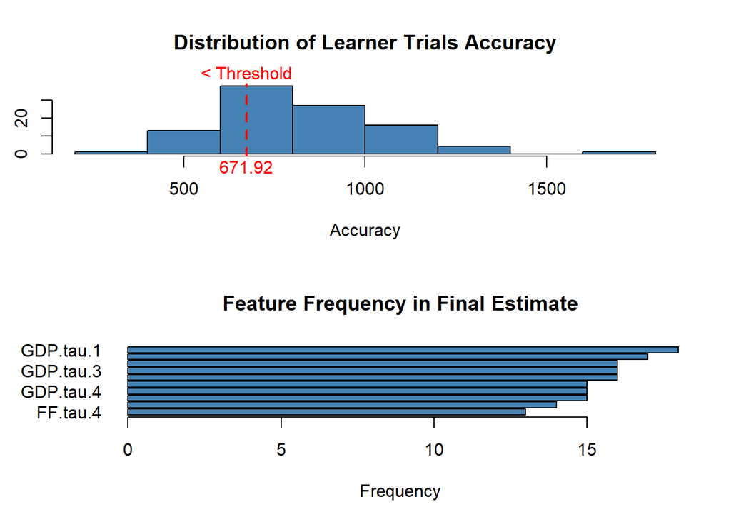

```
## [1] "NNS Boost R2: 0.894337555222808"
```

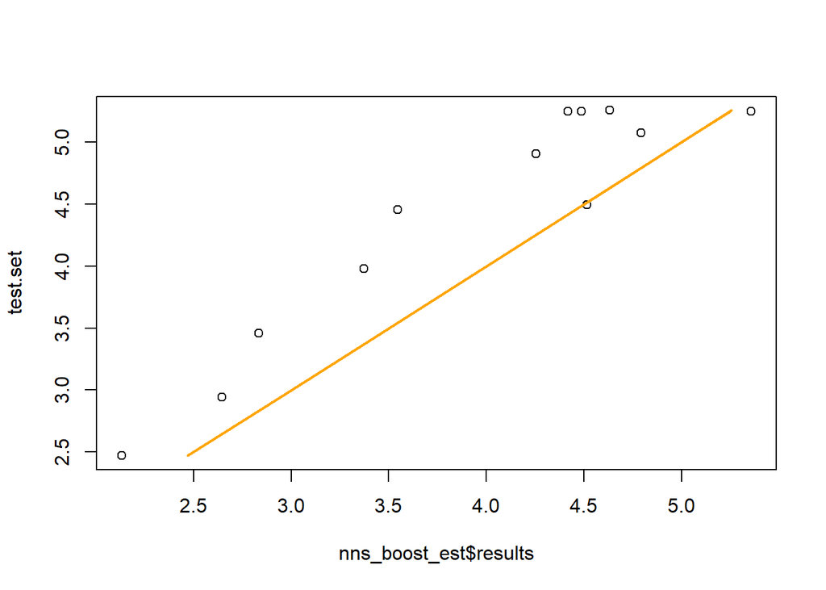

```
## [1] "NNS Regression R2: 0.981756173528187"
```

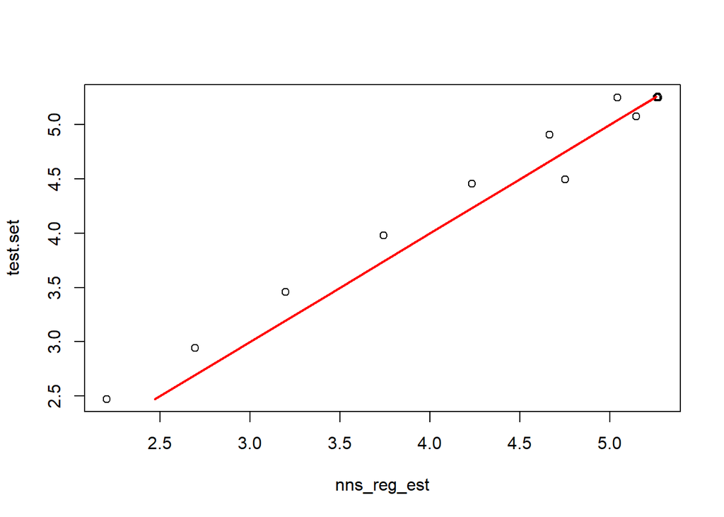

```
## [1] "Random Forest R2: 0.918219486502062"
```

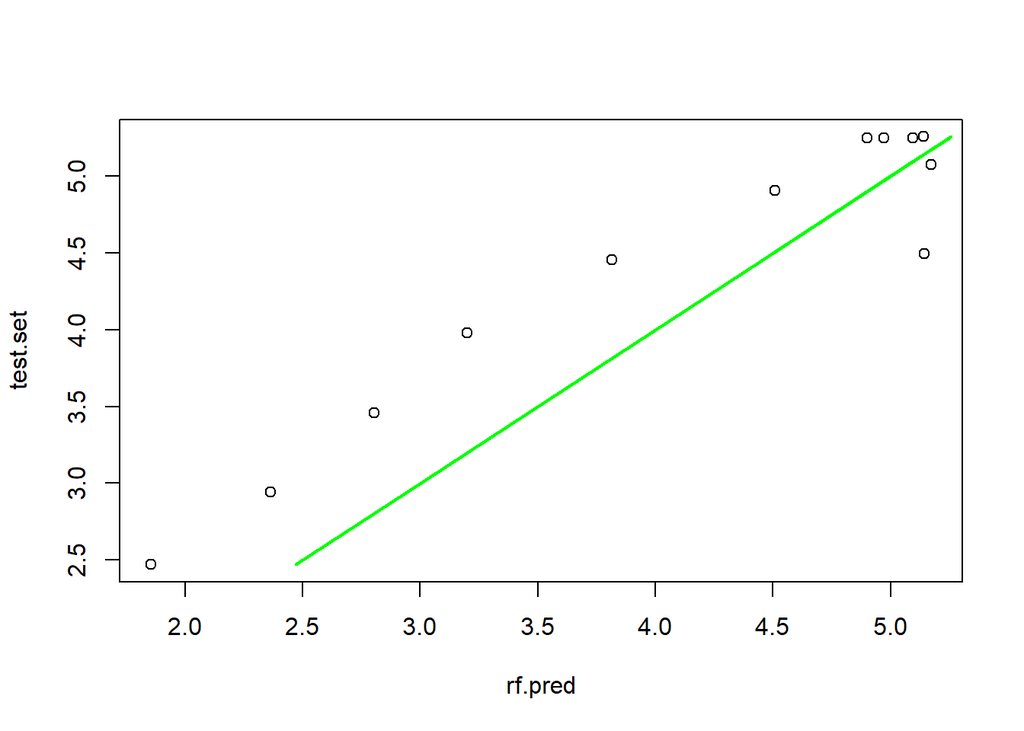

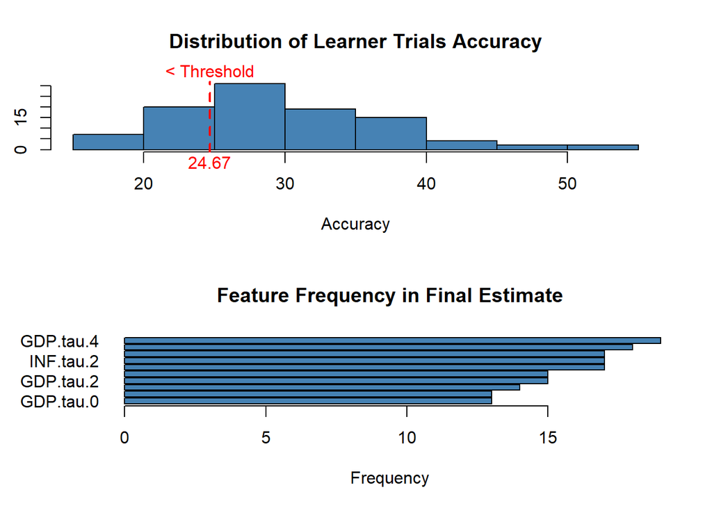

```
## [1] "NNS Boost R2: 1.73795533413192e-06"
```

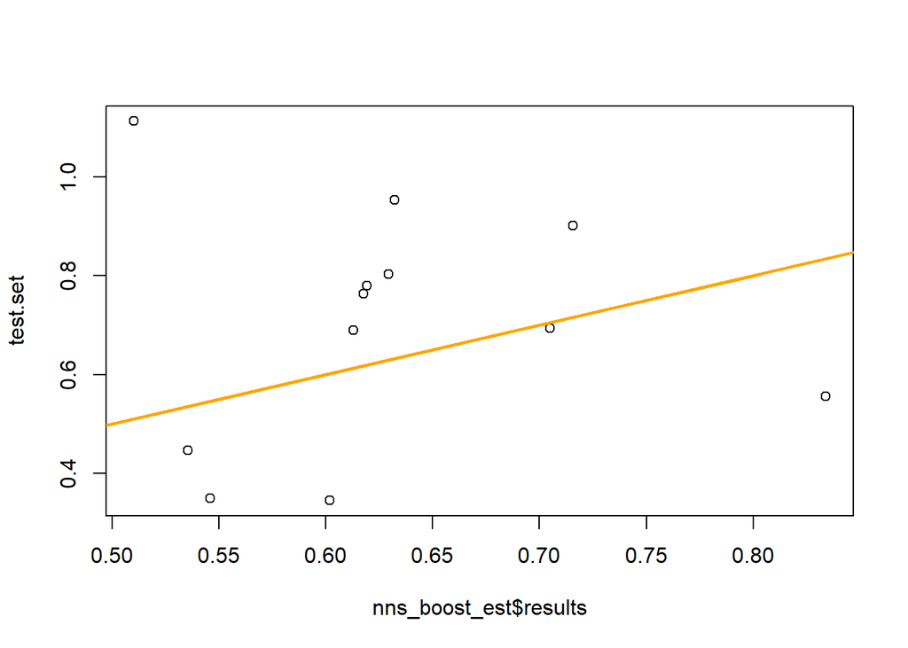

```
## [1] "NNS Regression R2: 0.999999110746633"
```

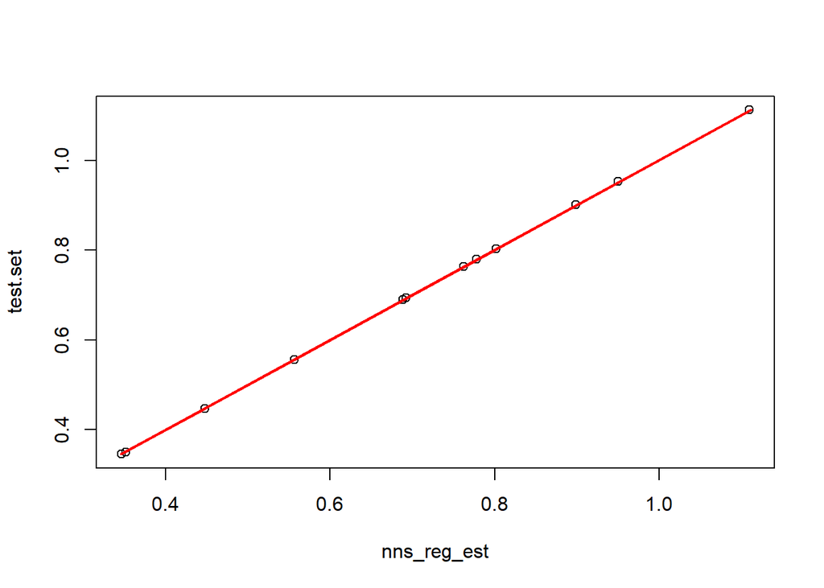

```
## [1] "Random Forest R2: 0.000453202150114564"
```

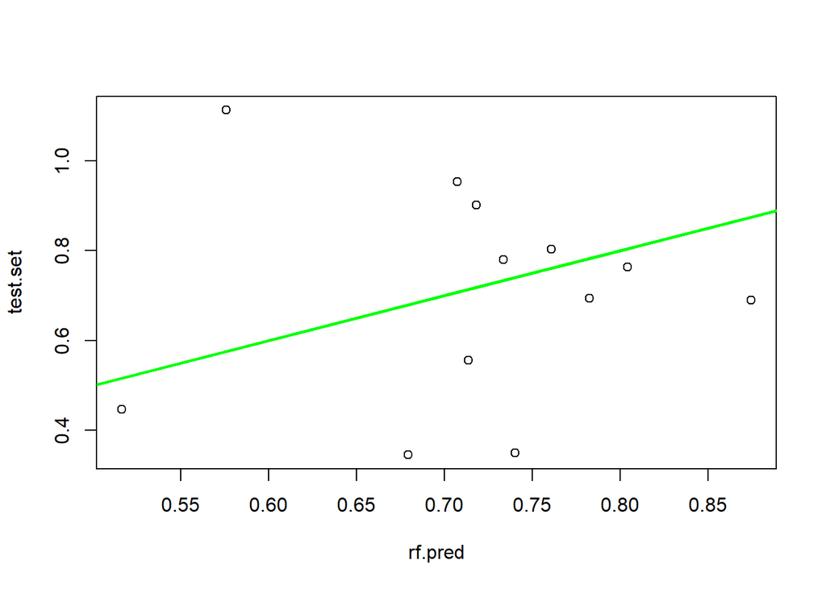

```r
train_l = dim(y)[1] - h
y_train = head(y, train_l)

y_test = tail(y, h)

# Select tau = 0 as DVs
DVs = which(grepl("tau.0", colnames(y)))

for(i in DVs){
  test.set = y_test[,i]

# NNS.boost() is an ensemble method comparable to xgboost, and aids in dimension reduction
  nns_boost_est = NNS.boost(y_train[,-i], y_train[,i], IVs.test = y_test[,-i],
                            obj.fn = expression(sum((predicted - actual)^2)), objective = 'min',
                            learner.trials = 100, epochs = 100, ncores = 1, type = NULL)

  print(paste0("NNS Boost R2: ", cor(nns_boost_est$results, test.set)^2))
  plot(nns_boost_est$results, test.set)
  lines(test.set, test.set, col = 'orange', lwd = 2)

# NNS.stack() cross-validates the parameters of the multivariate NNS.reg() and dimension reduction NNS.reg()
  nns_reg_est = NNS.stack(y_train[,names(nns_boost_est$feature.weights)%in%colnames(y_train)], y_train[,i],
                          IVs.test =  y_test[,names(nns_boost_est$feature.weights)%in%colnames(y_train)])$stack

  print(paste0("NNS Regression R2: ", cor(nns_reg_est, test.set)^2))
  plot(nns_reg_est, test.set)
  lines(test.set, test.set, col = 'red', lwd = 2)

# Random Forest
  rf = randomForest(y_train[,-i], y_train[,i])
  rf.pred = predict(rf, newdata = y_test[,-i])
  print(paste0("Random Forest R2: ", cor(rf.pred, test.set)^2))
  plot(rf.pred, test.set)
  lines(test.set, test.set, col = 'green', lwd = 2)
}
```

# 3 INTERPOLATE THE VALUES OF `realgnp` and `gnpdeflator` USING `NNS.reg()`

Now we will reverse the operations of interpolation to the highest frequency series, the monthly `Fed Funds`.

Note the final results of the interpolated values versus the original data. Scroll the output table to see all columns…

```r
# Name variable columns for joining
names(FF) = c("Year", "Month", "FF")

names(realgnp) = c("Year", "Month", "realgnp")

names(gnpdeflator) = c("Year", "Month", "gnpdeflator")


# Align quarterly data with corresponding month [1,2,3,4] -> [3,6,9,12]
realgnp[,2] = gnpdeflator[,2]*3
gnpdeflator[,2] = gnpdeflator[,2]*3


# Merge variable data.frames by Year and Month
a = Reduce(function(x,y) merge(x = x, y = y, by = c("Year", "Month"), all = TRUE),
       list(FF, realgnp, gnpdeflator))

# Create a row index to our reduced data.frame
a = cbind(index = 1:dim(a)[1], a)

# Create subsets of indicies and raw quarterly values
var1 = subset(a, select = c(index, realgnp))
var1 = var1[complete.cases(var1),]

var2 = subset(a, select = c(index, gnpdeflator))
var2 = var2[complete.cases(var2),]

head(var1)
```

|  | index | realgnp |
| --- | --- | --- |
| 1 | 1 | 2576.3 |
| 4 | 4 | 2628.2 |
| 7 | 7 | 2703.1 |
| 10 | 10 | 2746.5 |
| 13 | 13 | 2783.4 |
| 16 | 16 | 2800.4 |

```r
head(var2)
```

|  | index | gnpdeflator |
| --- | --- | --- |
| 1 | 1 | 15.279 |
| 4 | 4 | 15.322 |
| 7 | 7 | 15.396 |
| 10 | 10 | 15.460 |
| 13 | 13 | 15.570 |
| 16 | 16 | 15.723 |

```r
# Use NNS.reg() to interpolate the overall index and raw quarterly values
interpoloted_realgnp = NNS.reg(var1[, 1], var1[, 2],
                               point.est = a$index, order = 'max', plot = FALSE)$Point.est

interpoloted_gnpdeflator = NNS.reg(var2[,1], var2[,2],
                                   point.est = a$index, order = 'max', plot = FALSE)$Point.est

# Combine interpolated values to existing data.frame
b = cbind(a, interpoloted_realgnp, interpoloted_gnpdeflator)

head(b, 12)
```

|  | index | Year | Month | FF | realgnp | gnpdeflator | interpoloted_realgnp | interpoloted_gnpdeflator |
| --- | --- | --- | --- | --- | --- | --- | --- | --- |
| 1 | 1 | 1954 | 9 | NA | 2576.3 | 15.279 | 2576.300 | 15.27900 |
| 2 | 2 | 1954 | 10 | 0.85 | NA | NA | 2593.600 | 15.29333 |
| 3 | 3 | 1954 | 11 | 0.83 | NA | NA | 2610.900 | 15.30767 |
| 4 | 4 | 1954 | 12 | 1.28 | 2628.2 | 15.322 | 2628.200 | 15.32200 |
| 5 | 5 | 1955 | 1 | 1.39 | NA | NA | 2653.167 | 15.34667 |
| 6 | 6 | 1955 | 2 | 1.29 | NA | NA | 2678.133 | 15.37133 |
| 7 | 7 | 1955 | 3 | 1.35 | 2703.1 | 15.396 | 2703.100 | 15.39600 |
| 8 | 8 | 1955 | 4 | 1.43 | NA | NA | 2717.567 | 15.41733 |
| 9 | 9 | 1955 | 5 | 1.43 | NA | NA | 2732.033 | 15.43867 |
| 10 | 10 | 1955 | 6 | 1.64 | 2746.5 | 15.460 | 2746.500 | 15.46000 |

[output cut: 2 more lines]

# 4 Use Interpolated Variables

This step creates the new log differenced variables in a data.frame `y_new`.

```r
drgdp = diff(log(b$interpoloted_realgnp))*100
infl = diff(log(b$interpoloted_gnpdeflator))*100

y_new = cbind("Diff Real GDP" = drgdp,"Interest Rate" = na.omit(b$FF),"Inflation" = infl)
tail(y_new)
```

```
##        Diff Real GDP Interest Rate Inflation
## [634,]     0.3523624          5.26 0.1151979
## [635,]     0.3511252          5.02 0.1150654
## [636,]     0.3498966          4.94 0.1149331
## [637,]     0.2229670          4.76 0.1492841
## [638,]     0.2224710          4.49 0.1490616
## [639,]     0.2219771          4.24 0.1488397
```

# 5 Compare Predictions of Models

We will withhold 36 months of observations as the `test` set.

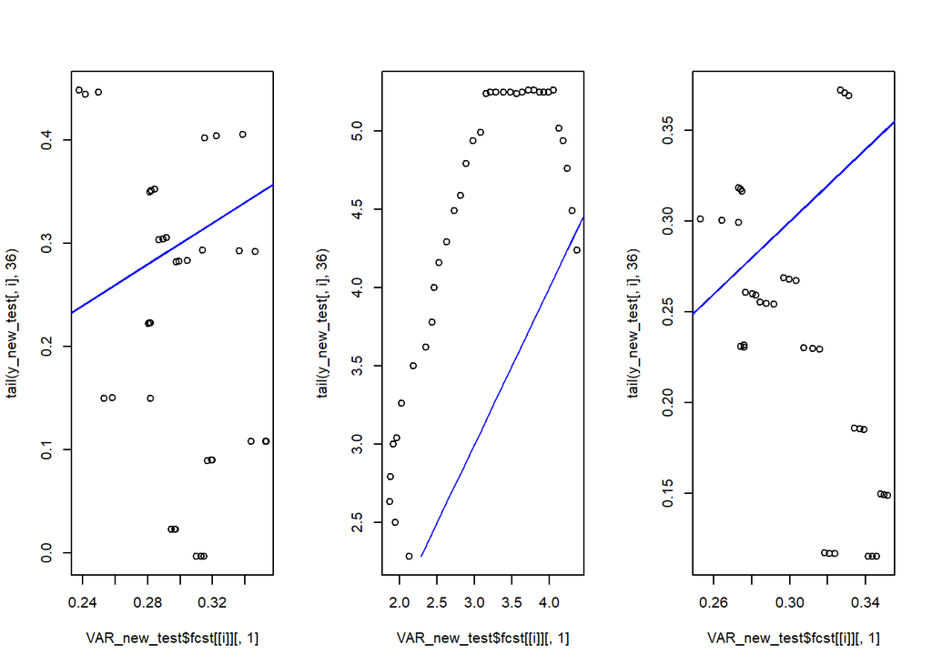

```r
# Forecast next 36 months
h = 36

# Create train and test sets for both versions
y_new_train = head(y_new, dim(y_new)[1] - h)
y_new_test = tail(y_new, h)

# 12 monthly lags used in VAR
VAR_new_train =  VAR(y = y_new_train, p = 12)
VAR_new_test = predict(VAR_new_train, n.ahead = 36)

par(mfrow=c(1,3))


# Plot predictions and actual values
for(i in 1:3){
  plot(VAR_new_test$fcst[[i]][,1], tail(y_new_test[,i], 36))
  lines(tail(y_new_test[,i],36), tail(y_new_test[,i], 36), col = 'blue')
}
```

```r
VAR_predictions = cbind(rbind(Diff.Real.GDP = cor(VAR_new_test$fcst[[1]][,1], tail(y_new_test[,1], 36))^2,
                              Interest.Rate = cor(VAR_new_test$fcst[[2]][,1], tail(y_new_test[,2], 36))^2,
                              Inflation = cor(VAR_new_test$fcst[[3]][,1], tail(y_new_test[,3], 36))^2)
                        )

colnames(VAR_predictions) = c("VAR Estimates correlation to Actual Values")

VAR_predictions
```

```
##               VAR Estimates correlation to Actual Values
## Diff.Real.GDP                                  0.1094934
## Interest.Rate                                  0.6547546
## Inflation                                      0.3219279
```

# 6 Other Methods

## 6.1 `NNS` and Random Forest

## 6.2 1 Year Lag $(\tau = 12)$, 3 Year Forecast $(h = 36)$

```r
tau = 12

y = cbind(lag.fx(cbind(GDP = drgdp, FF = FF$FF, INF = infl), tau))

head(y)
```

|  | GDP.tau.0 | GDP.tau.1 | GDP.tau.2 | GDP.tau.3 | GDP.tau.4 | GDP.tau.5 | GDP.tau.6 | GDP.tau.7 | GDP.tau.8 | GDP.tau.9 | GDP.tau.10 | GDP.tau.11 | GDP.tau.12 | FF.tau.0 | FF.tau.1 | FF.tau.2 | FF.tau.3 | FF.tau.4 | FF.tau.5 | FF.tau.6 | FF.tau.7 | FF.tau.8 | FF.tau.9 | FF.tau.10 | FF.tau.11 | FF.tau.12 | INF.tau.0 | INF.tau.1 | INF.tau.2 | … |
| --- | --- | --- | --- | --- | --- | --- | --- | --- | --- | --- | --- | --- | --- | --- | --- | --- | --- | --- | --- | --- | --- | --- | --- | --- | --- | --- | --- | --- | --- | --- |
| 1 | 0.2033810 | 0.4428849 | 0.4448551 | 0.4468429 | 0.5281231 | 0.5309271 | 0.5337610 | 0.9279228 | 0.9366139 | 0.9454694 | 0.6604212 | 0.6648117 | 0.6692611 | 2.24 | 2.18 | 1.96 | 1.68 | 1.64 | 1.43 | 1.43 | 1.35 | 1.29 | 1.39 | 1.28 | 0.83 | 0.85 | 0.3270177 | 0.2357733 | 0.2363305 | … |
| 2 | 0.2029682 | 0.2033810 | 0.4428849 | 0.4448551 | 0.4468429 | 0.5281231 | 0.5309271 | 0.5337610 | 0.9279228 | 0.9366139 | 0.9454694 | 0.6604212 | 0.6648117 | 2.35 | 2.24 | 2.18 | 1.96 | 1.68 | 1.64 | 1.43 | 1.43 | 1.35 | 1.29 | 1.39 | 1.28 | 0.83 | 0.3259518 | 0.3270177 | 0.2357733 | … |
| 3 | 0.2025571 | 0.2029682 | 0.2033810 | 0.4428849 | 0.4448551 | 0.4468429 | 0.5281231 | 0.5309271 | 0.5337610 | 0.9279228 | 0.9366139 | 0.9454694 | 0.6604212 | 2.48 | 2.35 | 2.24 | 2.18 | 1.96 | 1.68 | 1.64 | 1.43 | 1.43 | 1.35 | 1.29 | 1.39 | 1.28 | 0.3248928 | 0.3259518 | 0.3270177 | … |
| 4 | -0.1036103 | 0.2025571 | 0.2029682 | 0.2033810 | 0.4428849 | 0.4448551 | 0.4468429 | 0.5281231 | 0.5309271 | 0.5337610 | 0.9279228 | 0.9366139 | 0.9454694 | 2.45 | 2.48 | 2.35 | 2.24 | 2.18 | 1.96 | 1.68 | 1.64 | 1.43 | 1.43 | 1.35 | 1.29 | 1.39 | 0.3344060 | 0.3248928 | 0.3259518 | … |
| 5 | -0.1037178 | -0.1036103 | 0.2025571 | 0.2029682 | 0.2033810 | 0.4428849 | 0.4448551 | 0.4468429 | 0.5281231 | 0.5309271 | 0.5337610 | 0.9279228 | 0.9366139 | 2.50 | 2.45 | 2.48 | 2.35 | 2.24 | 2.18 | 1.96 | 1.68 | 1.64 | 1.43 | 1.43 | 1.35 | 1.29 | 0.3332915 | 0.3344060 | 0.3248928 | … |
| 6 | -0.1038254 | -0.1037178 | -0.1036103 | 0.2025571 | 0.2029682 | 0.2033810 | 0.4428849 | 0.4448551 | 0.4468429 | 0.5281231 | 0.5309271 | 0.5337610 | 0.9279228 | 2.50 | 2.50 | 2.45 | 2.48 | 2.35 | 2.24 | 2.18 | 1.96 | 1.68 | 1.64 | 1.43 | 1.43 | 1.35 | 0.3321843 | 0.3332915 | 0.3344060 | … |

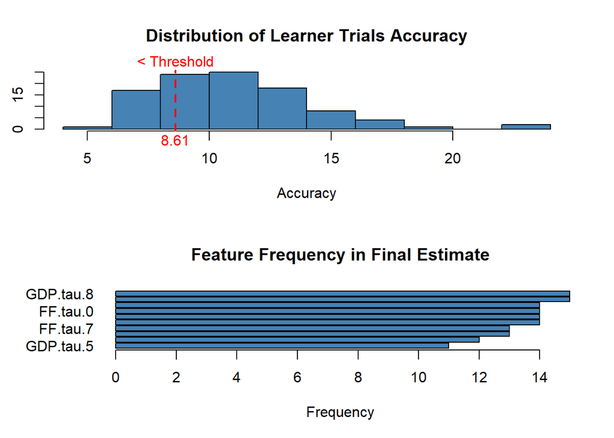

```
## [1] "NNS Boost R2: 0.00834931428502958"
```

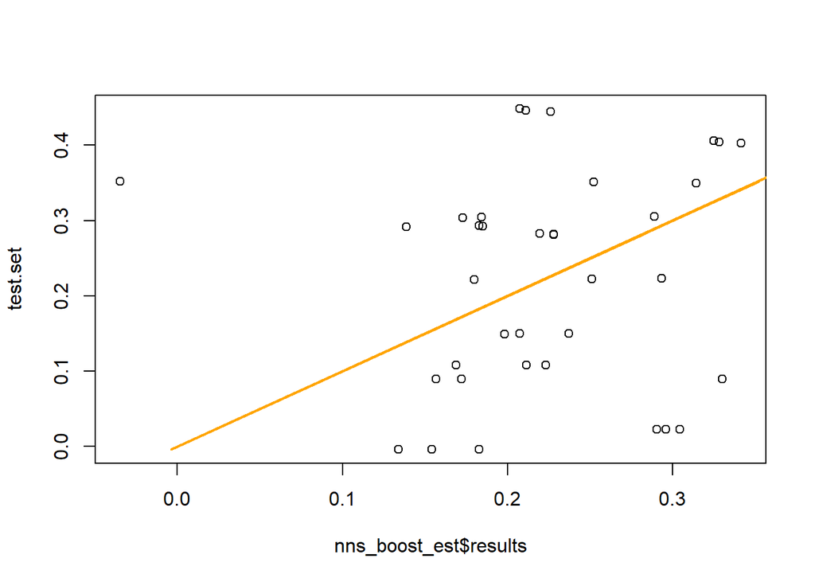

```
## [1] "NNS Regression R2: 0.420547351642026"
```

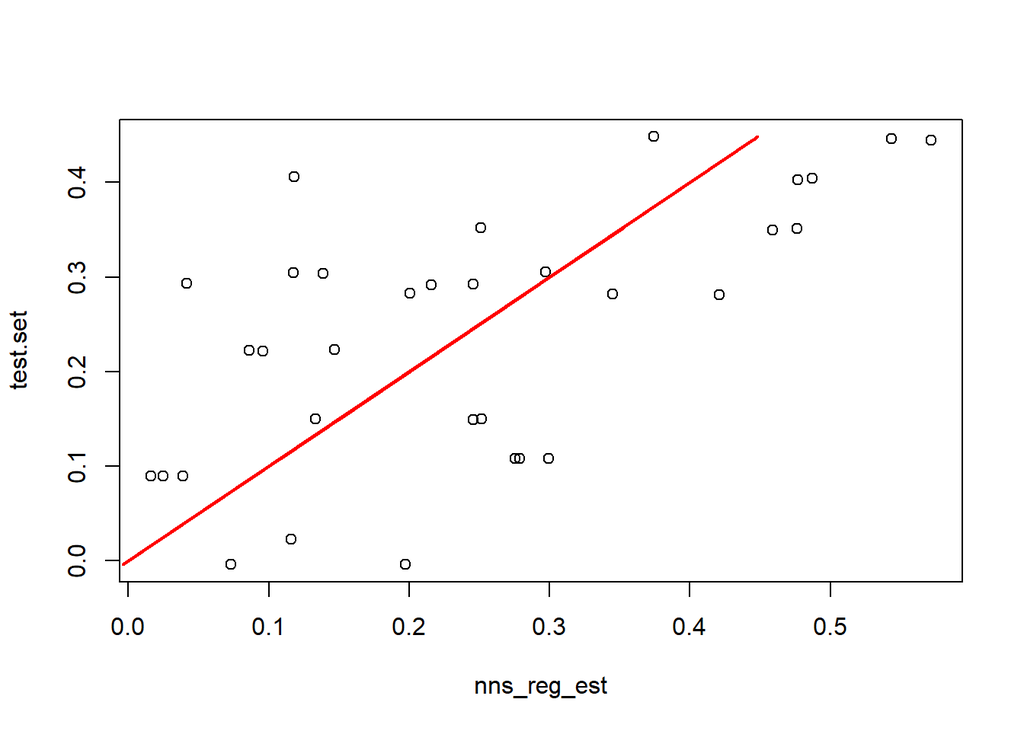

```
## [1] "Random Forest R2: 0.426254067286565"
```

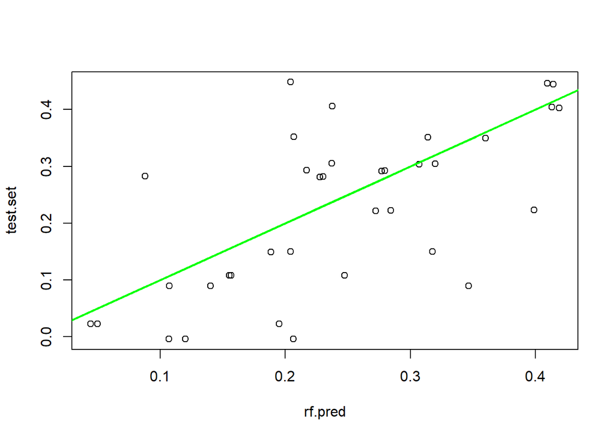

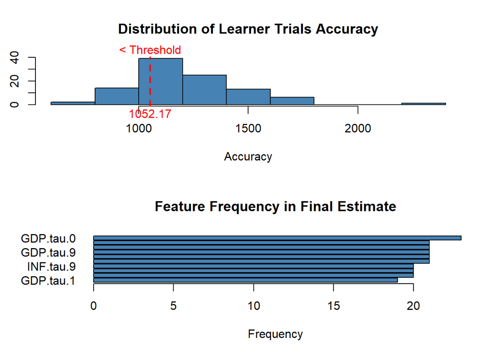

```
## [1] "NNS Boost R2: 0.87444689394948"
```

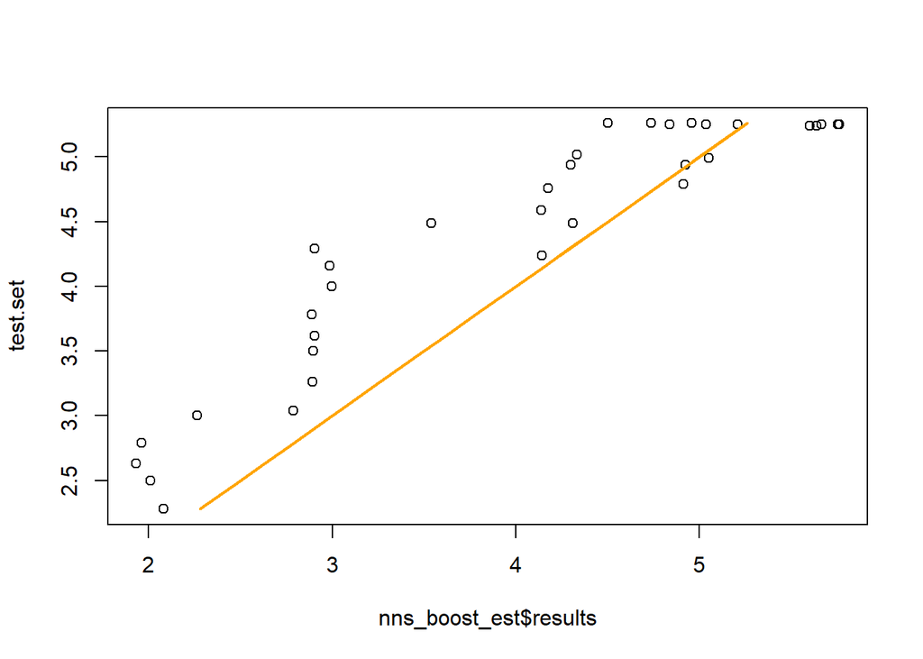

```
## [1] "NNS Regression R2: 0.979852892440326"
```

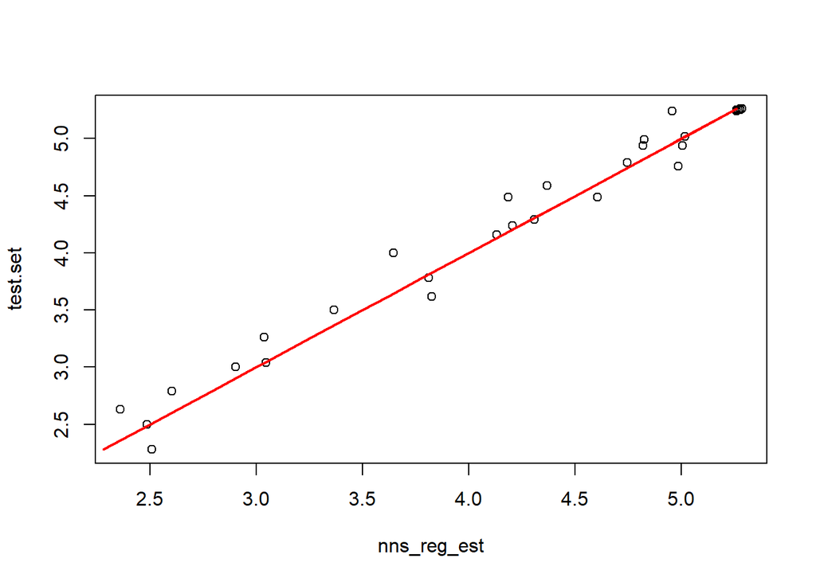

```
## [1] "Random Forest R2: 0.982608600777348"
```

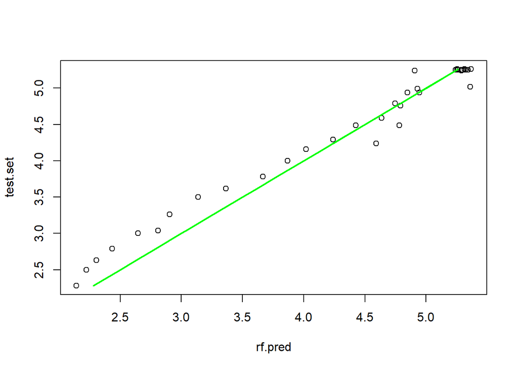

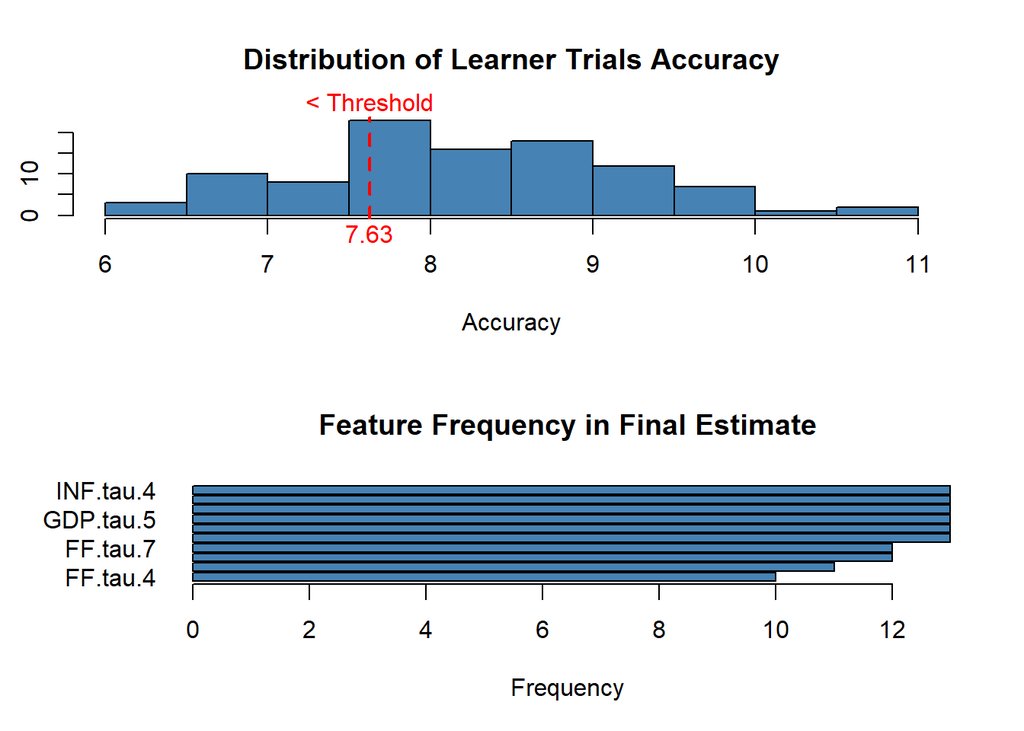

```
## [1] "NNS Boost R2: 0.145394712843636"
```

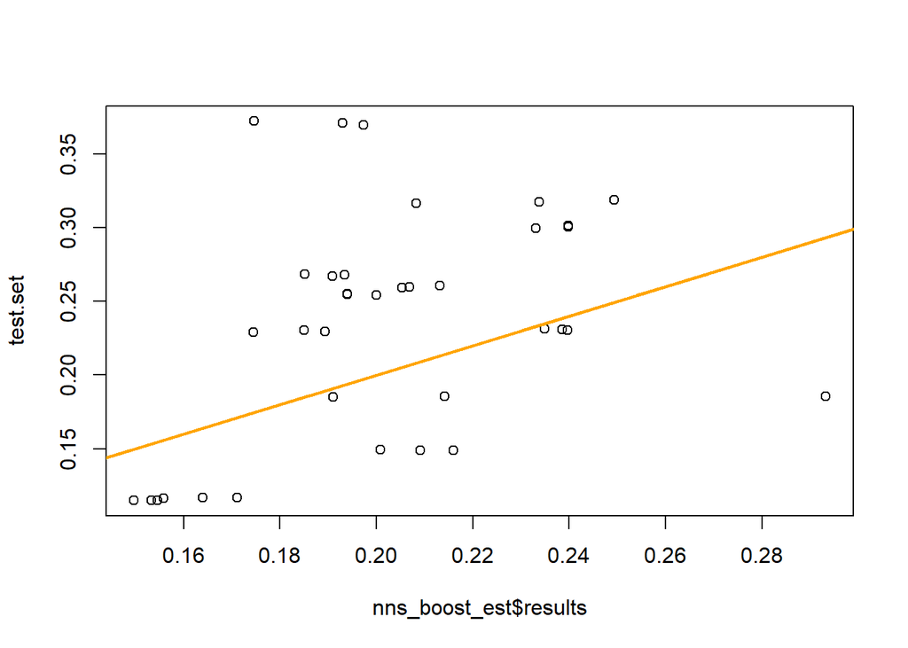

```
## [1] "NNS Regression R2: 0.639249876817106"
```

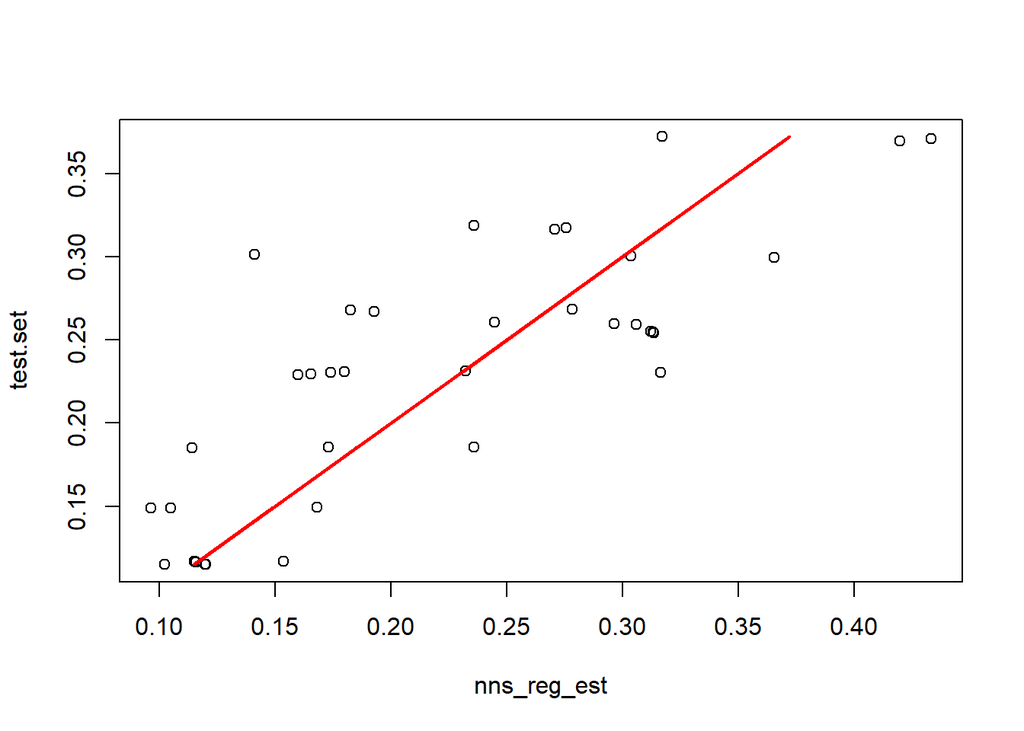

```
## [1] "Random Forest R2: 0.405837204415908"
```

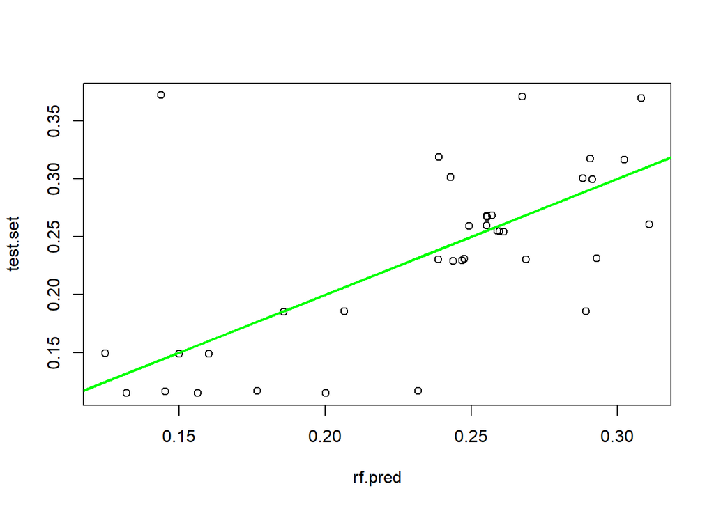

```r
train_l = dim(y)[1] - h
y_train = head(y, train_l)

y_test = tail(y, h)

DVs = which(grepl("tau.0", colnames(y)))

for(i in DVs){
  test.set = y_test[,i]

# NNS.boost() is an ensemble method comparable to xgboost, and aids in dimension reduction
  nns_boost_est = NNS.boost(y_train[,-i], y_train[,i], IVs.test = y_test[,-i],
                            obj.fn = expression(sum((predicted - actual)^2)), objective = 'min',
                            learner.trials = 100, epochs = 100, ncores = 1, type = NULL)

  print(paste0("NNS Boost R2: ", cor(nns_boost_est$results, test.set)^2))
  plot(nns_boost_est$results, test.set)
  lines(test.set, test.set, col = 'orange', lwd = 2)

# NNS.stack() cross-validates the parameters of the multivariate NNS.reg() and dimension reduction NNS.reg()
  nns_reg_est = NNS.stack(y_train[,names(nns_boost_est$feature.weights)%in%colnames(y_train)], y_train[,i],
                          IVs.test = y_test[,names(nns_boost_est$feature.weights)%in%colnames(y_train)])$stack

  print(paste0("NNS Regression R2: ", cor(nns_reg_est, test.set)^2))
  plot(nns_reg_est, test.set)
  lines(test.set, test.set, col = 'red', lwd = 2)

# Random Forest
  rf = randomForest(y_train[,-i], y_train[,i])
  rf.pred = predict(rf, newdata = y_test[,-i])
  print(paste0("Random Forest R2: ", cor(rf.pred, test.set)^2))
  plot(rf.pred, test.set)
  lines(test.set, test.set, col = 'green', lwd = 2)
}
```

# 7 Comments

Unlike random forests, `NNS` has interpretability, albeit less straightforward than the VAR. Furthermore, `NNS` can extrapolate well beyond observed ranges, whereby random forests cannot. Finally, multivariate partial derivatives can be extracted using the finite step method, which `NNS` has a routine for, `dy.d_` to aid in policy decisions.

This is still a very active area of development, and all questions / comments are welcomed! \ email: fviole@fordham.edu

Thank you for your interest!

[^1]: Data available for download at the following: https://sites.google.com/site/lkilian2019/